# nfl-analysis

Lucas Paiva

2024-02-11

Let’s work a little bit with NFL data from the nflfastR package in CRAN.

```r
#Libraries:
library(dplyr)
library(ggplot2)
library(nflfastR)
```

We need to upload the available NFL Data.

```r
#Uploading NFL Data:
#Play by Play Data:
data_pbp_2022 = load_pbp(season = 2022)
head(data_pbp_2022, 5)
```

```
## # A tibble: 5 × 372
##   play_id game_id  old_g…¹ home_…² away_…³ seaso…⁴  week posteam poste…⁵ defteam
##     <dbl> <chr>    <chr>   <chr>   <chr>   <chr>   <int> <chr>   <chr>   <chr>
## 1       1 2022_01… 202209… NYJ     BAL     REG         1 <NA>    <NA>    <NA>
## 2      43 2022_01… 202209… NYJ     BAL     REG         1 NYJ     home    BAL
## 3      68 2022_01… 202209… NYJ     BAL     REG         1 NYJ     home    BAL
## 4      89 2022_01… 202209… NYJ     BAL     REG         1 NYJ     home    BAL
## 5     115 2022_01… 202209… NYJ     BAL     REG         1 NYJ     home    BAL
## # … with 362 more variables: side_of_field <chr>, yardline_100 <dbl>,
## #   game_date <chr>, quarter_seconds_remaining <dbl>,
## #   half_seconds_remaining <dbl>, game_seconds_remaining <dbl>,
## #   game_half <chr>, quarter_end <dbl>, drive <dbl>, sp <dbl>, qtr <dbl>,
## #   down <dbl>, goal_to_go <dbl>, time <chr>, yrdln <chr>, ydstogo <dbl>,
## #   ydsnet <dbl>, desc <chr>, play_type <chr>, yards_gained <dbl>,
## #   shotgun <dbl>, no_huddle <dbl>, qb_dropback <dbl>, qb_kneel <dbl>, …
## # ℹ Use `colnames()` to see all variable names
```

```r
#Players Stats:
data_players_stats = load_player_stats(season = 2022)
head(data_players_stats, 5)
```

```
## # A tibble: 5 × 53
##   player_id playe…¹ playe…² posit…³ posit…⁴ heads…⁵ recen…⁶ season  week seaso…⁷
##   <chr>     <chr>   <chr>   <chr>   <chr>   <chr>   <chr>    <int> <int> <chr>
## 1 00-00195… T.Brady Tom Br… QB      QB      https:… TB        2022     1 REG
## 2 00-00195… T.Brady Tom Br… QB      QB      https:… TB        2022     2 REG
## 3 00-00195… T.Brady Tom Br… QB      QB      https:… TB        2022     3 REG
## 4 00-00195… T.Brady Tom Br… QB      QB      https:… TB        2022     4 REG
## 5 00-00195… T.Brady Tom Br… QB      QB      https:… TB        2022     5 REG
## # … with 43 more variables: completions <int>, attempts <int>,
## #   passing_yards <dbl>, passing_tds <int>, interceptions <dbl>, sacks <dbl>,
## #   sack_yards <dbl>, sack_fumbles <int>, sack_fumbles_lost <int>,
## #   passing_air_yards <dbl>, passing_yards_after_catch <dbl>,
## #   passing_first_downs <dbl>, passing_epa <dbl>,
## #   passing_2pt_conversions <int>, pacr <dbl>, dakota <dbl>, carries <int>,
## #   rushing_yards <dbl>, rushing_tds <int>, rushing_fumbles <dbl>, …
## # ℹ Use `colnames()` to see all variable names
```

So, we got a lot of data available of the 2022 NFL Season, I loaded to dataframes into R from the package repository:

- *data_pbp_2022* = play by play data from all 2022 NFL’s Games from all teams
- *data_players_stats* = players stats from all weeks

With this data we can look into some stuff that can help us understand what are the realy good teams and players, also I want to see if some of my favorites players are playing well and if they are corresponding my expectations.

After loading the data, since we got so many variables, especially in the play by play data, we need to see what are the columns that helps us out to reach our goal, so we can use the field descriptions available from the nflfastR to chose the columns we want.

```r
#Fields Descriptions:
field_descriptions |>
  mutate(print_string = paste(Field, Description, sep = ": ")) |>
  select(Field, print_string)
```

```
## # A tibble: 372 × 2
##    Field        print_string
##    <chr>        <chr>
##  1 play_id      play_id: Numeric play id that when used with game_id and drive …
##  2 game_id      game_id: Ten digit identifier for NFL game.
##  3 old_game_id  old_game_id: Legacy NFL game ID.
##  4 home_team    home_team: String abbreviation for the home team.
##  5 away_team    away_team: String abbreviation for the away team.
##  6 season_type  season_type: 'REG' or 'POST' indicating if the game belongs to …
##  7 week         week: Season week.
##  8 posteam      posteam: String abbreviation for the team with possession.
##  9 posteam_type posteam_type: String indicating whether the posteam team is hom…
## 10 defteam      defteam: String abbreviation for the team on defense.
## # … with 362 more rows
## # ℹ Use `print(n = ...)` to see more rows
```

To chose the columns I want, I concatenated the field name and descriptions and clipped this to a simple sheet (Excel, LibreOffice, Google Sheets..) and started to check the columns I wanted, after I checked I the columns we just need to clip back to R and select only the fields we want.

```r
#Selecting fields we want:
data_pbp_2022_sel_fieds = data_pbp_2022 |>
  select(play_id,
game_id,
home_team,
away_team,
season_type,
week,
posteam,
defteam,
game_date,
drive,
sp,
qtr,
down,
yrdln,
desc,
play_type,
qb_dropback,
qb_scramble,
pass_length,
pass_location,
air_yards,
rushing_yards,
yards_after_catch,
td_team,
td_player_name,
posteam_score,
defteam_score,
penalty,
epa,
total_home_epa,
total_away_epa,
total_home_rush_epa,
total_away_rush_epa,
total_home_pass_epa,
total_away_pass_epa,
first_down_rush,
first_down_pass,
first_down_penalty,
third_down_converted,
third_down_failed,
fourth_down_converted,
fourth_down_failed,
away_score,
home_score,
location,
result,
spread_line,
passer_id
)
```

```r
str(data_pbp_2022_sel_fieds)
```

```
## nflverse_data [50,147 × 48] (S3: nflverse_data/tbl_df/tbl/data.table/data.frame)
##  $ play_id              : num [1:50147] 1 43 68 89 115 136 172 202 230 254 ...
##  $ game_id              : chr [1:50147] "2022_01_BAL_NYJ" "2022_01_BAL_NYJ" "2022_01_BAL_NYJ" "2022_01_BAL_NYJ" ...
##  $ home_team            : chr [1:50147] "NYJ" "NYJ" "NYJ" "NYJ" ...
##  $ away_team            : chr [1:50147] "BAL" "BAL" "BAL" "BAL" ...
##  $ season_type          : chr [1:50147] "REG" "REG" "REG" "REG" ...
##  $ week                 : int [1:50147] 1 1 1 1 1 1 1 1 1 1 ...
##  $ posteam              : chr [1:50147] NA "NYJ" "NYJ" "NYJ" ...
##  $ defteam              : chr [1:50147] NA "BAL" "BAL" "BAL" ...
##  $ game_date            : chr [1:50147] "2022-09-11" "2022-09-11" "2022-09-11" "2022-09-11" ...
##  $ drive                : num [1:50147] NA 1 1 1 1 1 1 2 2 2 ...
##  $ sp                   : num [1:50147] 0 0 0 0 0 0 0 0 0 0 ...
##  $ qtr                  : num [1:50147] 1 1 1 1 1 1 1 1 1 1 ...
##  $ down                 : num [1:50147] NA NA 1 1 2 3 4 1 2 3 ...
##  $ yrdln                : chr [1:50147] "BAL 35" "BAL 35" "NYJ 22" "NYJ 41" ...
```

[output cut: 38 more lines]

Since we have play by play data, this dataset has a lot of NA values, because some columns only apply to specific plays, example, the *air_yards* variable will only have values when the play is a pass from the possession team.

Here, we need to create our dataframes using this available data, we don’t have a organized dataset with the teams statistics by week and etc, therefore, we need to do some cleaning and aggregation steps. But since we have offensive and defensive plays in the same datasets, we need to orient our data handling to the visuals we want to create, so lets work on it.

### How are the Teams Tiers by Winning Pctg?

[figure not shown]

```r
#Creating our wins dataframe by week:
df_wins = data_pbp_2022_sel_fieds |>
  select(game_id, home_team, away_team, week, result) |> unique() |>
  mutate(win = if_else(result <= 0, 0, 1)) #Creating a Win flag

#Adjusting to calculate all wins for all teams:
df_wins_adj = rbind(#Home Teams Wins:
      df_wins |>
        select(game_id, home_team, result, win) |>
        rename(team_abbr = home_team),
      #Away Teams Wins:
      df_wins |>
        select(game_id, away_team, result, win) |>
        rename(team_abbr = away_team) |>
        mutate(win = abs(win - 1))
      )

#Plotting:
asp_ratio <- 1.618

df_wins_adj |>
  inner_join(select(teams_colors_logos, team_name, team_abbr, team_logo_espn), by = "team_abbr") |>
  group_by(team_logo_espn, team_abbr, team_name) |>
  summarise("Games Played" = n(),
            "% Win" = sum(win)/n()) |>
  ##ggplot part:
  ggplot(aes(x = reorder(team_name, -`% Win`), y = `% Win`)) +
  geom_bar(stat = "identity", alpha = 0.8, col = "black") +
  ggimage::geom_image(aes(image = team_logo_espn),
                      size = 0.05, by = "width", asp = asp_ratio) +
  scale_y_continuous(labels = scales::percent) +
  theme_classic() +
  theme(axis.text.x = element_blank(),
        aspect.ratio = 1/asp_ratio) +
  labs(x = "Teams", y = "Winning Percentage",
       title = "Winning Percentage by Team Throught 8 Weeks")
```

### Offensive and Defensive EPA

EPA is a very good measure for evaluating how good the teams units are playing.

[figure not shown]

```r
#Off and Def EPA per Play:
data_pbp_2022_sel_fieds |>
  select(game_id, play_id, posteam, defteam, week, epa) |>
  na.omit() |>
  tidyr::pivot_longer(c("posteam", "defteam"), names_to = "unit", values_to = "team_abbr") |>
  mutate(unit = factor(unit, levels = c("posteam", "defteam"), labels = c("offense", "defense"))) |>
  group_by(team_abbr, unit) |> summarise(avg_epa = mean(epa)) |> ungroup() |>
  tidyr::spread(unit, avg_epa) |>
  inner_join(select(teams_colors_logos, team_name, team_abbr, team_logo_espn), by = "team_abbr") |>
  ##ggplot aprt:
  ggplot(aes(x = offense, y = defense)) +
  geom_point(col = "white") +
  ggimage::geom_image(aes(image = team_logo_espn),
                      size = 0.05, by = "width", asp = asp_ratio) +
  theme_classic() +
  labs(x = "EPA/Play (Offense)",
       y = "EPA/Play (Defense)",
       title = "EPA by Team")
```

### Play Selection Around the League

Here we got evaluate the play selection by each down and after we can look into it by each team.

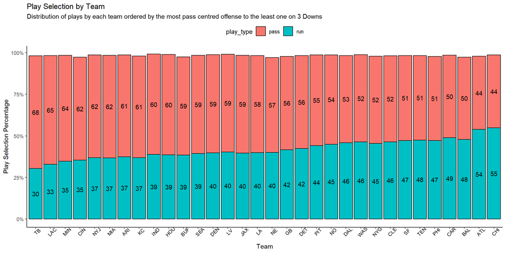

```r
#Plays Types in the dataset:
df_plays = data_pbp_2022_sel_fieds |>
  filter(down %in% c(1, 2, 3) & penalty == 0) |>
  select(game_id, posteam, play_type, down, week) |>
  group_by(posteam, play_type) |> summarise(n = n()) |> mutate(freq = n/sum(n)) |>
  select(-n) |> filter(play_type %in% c("run", "pass")) |>
  arrange(play_type, desc(freq)) |> group_by(play_type) |>
  mutate(id = if_else(play_type == "pass", row_number(), NULL)) |> ungroup() |>
  group_by(posteam) |> mutate(id = sum(id, na.rm = T)) #This part is just to order the axis by the play type category


##ggplot part:
df_plays |>
  ggplot(aes(x = reorder(posteam, id), y = freq, fill = play_type, label = round(freq*100, 0))) +
  geom_bar(stat = "identity", col = "black") +
  theme_classic() +
  geom_text(position = position_stack(vjust = .5)) +
  theme(axis.text.x = element_text(angle = 45, colour = "black"),
        legend.position = "top") +
  scale_y_continuous(labels = scales::percent) +
  labs(x = "Team",
       y = "Play Selection Percentage",
       title = "Play Selection by Team",
       subtitle = "Distribution of plays by each team ordered by the most pass centred offense to the least one on 3 Downs")
```

### Air Yards versus Rush Yards per Play

[figure not shown]

```r
data_pbp_2022_sel_fieds |>
  select(game_id, play_id, posteam, air_yards, rushing_yards, play_type, penalty) |>
  filter(!is.na(play_type) & play_type %in% c("run", "pass")) |>
  group_by(posteam) |> summarise(avg_air = mean(air_yards, na.rm = T),
                                 avg_rush = mean(rushing_yards, na.rm = T)) |>
  rename(team_abbr = posteam) |>
  inner_join(select(teams_colors_logos, team_name, team_abbr, team_logo_espn), by = "team_abbr") |>
  ggplot(aes(x = avg_air, y = avg_rush)) +
  geom_point(col = "white") +
  ggimage::geom_image(aes(image = team_logo_espn),
                      size = 0.05, by = "width", asp = asp_ratio) +
  theme_classic() +
  labs(x = "Air Yards per Play",
       y = "Rush Yards per Play",
       title = "Air Yards versus Rush Yards per Play by Team")
```

### Play Selection and Field Position

For this one some manipulations have to be done.

```r
`%!in%` = Negate(`%in%`)
df_fields_plays_downs = data_pbp_2022_sel_fieds |>
  select(play_id, game_id, posteam, yrdln, play_type, down) |>
  filter(!is.na(play_type) & play_type %!in% c("no_play", "kickoff", "extra_point") & !is.na(down)) |>
  mutate(adj_play = forcats::fct_lump_n(play_type, n = 4, ties.method = "first", other_level = "Others Plays"), #Plays "Irrelevants" won't mather
         field_position_num = if_else(stringr::word(yrdln, 1) == posteam, as.numeric(paste0("-", stringr::word(yrdln, 2))), as.numeric(stringr::word(yrdln, 2))),
         field_position_cat = case_when(field_position_num <= -30 ~ "Own 20",
                                        field_position_num > -30 & field_position_num <= 0 ~ "Defensive Field > 20 Yrds",
                                        field_position_num > 0 & field_position_num <= 30 ~ "Offensive Field - Not Red Zone",
                                        T ~  "Red Zone"), #Creating categories for field position
         field_position_cat = factor(field_position_cat, levels = c("Own 20", "Defensive Field > 20 Yrds", "Offensive Field - Not Red Zone", "Red Zone")))
#Aggregation Part:
stats_fields_plays = df_fields_plays_downs |>
  group_by(posteam, field_position_cat, adj_play) |>
  summarise(n = n()) |> mutate(freq = n/sum(n)) |> select(-n) |>
  tidyr::spread(adj_play, freq)
stats_fields_plays[is.na(stats_fields_plays)] = 0
stats_fields_plays |> ungroup() |>
  inner_join(select(teams_colors_logos, team_abbr, team_name), by = c("posteam" = "team_abbr")) |> select(-posteam) |>
  select(team_name, field_position_cat, pass, run, field_goal, punt, `Others Plays`) |>
  mutate_if(is.double, scales::percent, accuracy = 0.1) |>
  knitr::kable(align = "c")
```

| team_name | field_position_cat | pass | run | field_goal | punt | Others Plays |
| --- | --- | --- | --- | --- | --- | --- |
| Arizona Cardinals | Own 20 | 58.9% | 32.9% | 0.0% | 7.9% | 0.3% |
| Arizona Cardinals | Defensive Field > 20 Yrds | 62.7% | 27.7% | 0.0% | 8.8% | 0.8% |
| Arizona Cardinals | Offensive Field - Not Red Zone | 50.4% | 39.5% | 8.6% | 0.0% | 1.5% |
| Arizona Cardinals | Red Zone | 51.6% | 40.8% | 3.6% | 2.8% | 1.2% |
| Atlanta Falcons | Own 20 | 43.1% | 48.0% | 0.0% | 8.8% | 0.0% |
| Atlanta Falcons | Defensive Field > 20 Yrds | 45.6% | 43.2% | 0.0% | 9.2% | 2.0% |
| Atlanta Falcons | Offensive Field - Not Red Zone | 32.7% | 55.8% | 9.0% | 0.0% | 2.5% |
| Atlanta Falcons | Red Zone | 39.2% | 51.7% | 5.2% | 3.4% | 0.4% |
| Baltimore Ravens | Own 20 | 45.5% | 42.4% | 0.0% | 8.8% | 3.3% |
| Baltimore Ravens | Defensive Field > 20 Yrds | 53.3% | 38.9% | 0.0% | 6.0% | 1.8% |
| Baltimore Ravens | Offensive Field - Not Red Zone | 41.4% | 49.0% | 9.6% | 0.0% | 0.0% |
| Baltimore Ravens | Red Zone | 40.4% | 47.4% | 5.5% | 4.0% | 2.6% |
| Buffalo Bills | Own 20 | 59.0% | 31.0% | 0.0% | 8.9% | 1.1% |
| Buffalo Bills | Defensive Field > 20 Yrds | 59.5% | 33.2% | 0.0% | 6.2% | 1.2% |
| Buffalo Bills | Offensive Field - Not Red Zone | 49.0% | 40.2% | 7.7% | 0.0% | 3.1% |
| Buffalo Bills | Red Zone | 54.0% | 39.4% | 2.4% | 2.4% | 1.7% |
| Carolina Panthers | Own 20 | 47.0% | 40.2% | 0.0% | 12.2% | 0.7% |
| Carolina Panthers | Defensive Field > 20 Yrds | 48.6% | 40.5% | 0.0% | 10.6% | 0.3% |
| Carolina Panthers | Offensive Field - Not Red Zone | 37.1% | 49.8% | 12.4% | 0.0% | 0.8% |
| Carolina Panthers | Red Zone | 45.5% | 46.0% | 1.8% | 4.9% | 1.8% |
| Chicago Bears | Own 20 | 43.4% | 48.6% | 0.0% | 7.7% | 0.3% |
| Chicago Bears | Defensive Field > 20 Yrds | 40.5% | 47.4% | 0.0% | 10.6% | 1.6% |
| Chicago Bears | Offensive Field - Not Red Zone | 32.2% | 56.5% | 8.6% | 0.4% | 2.4% |
| Chicago Bears | Red Zone | 43.5% | 49.5% | 2.5% | 4.0% | 0.5% |
| Cincinnati Bengals | Own 20 | 62.1% | 28.6% | 0.0% | 8.6% | 0.7% |
| Cincinnati Bengals | Defensive Field > 20 Yrds | 54.5% | 33.0% | 0.0% | 9.0% | 3.5% |
| Cincinnati Bengals | Offensive Field - Not Red Zone | 53.7% | 36.2% | 8.1% | 0.0% | 2.0% |
| Cincinnati Bengals | Red Zone | 58.4% | 34.5% | 1.7% | 2.4% | 3.1% |
| Cleveland Browns | Own 20 | 54.2% | 39.5% | 0.0% | 6.0% | 0.3% |
| Cleveland Browns | Defensive Field > 20 Yrds | 48.8% | 41.2% | 0.0% | 8.6% | 1.3% |

[output cut: 98 more lines]